# IODS course project

Ida Alakörkkö

# *Introduction to Open Data Science - Course Project*

Introduction to Open Data Science is a course for anyone interested in learning how to use RStudio, R Markdown, and GitHub (state-of-the-art data science tools) to visualize and analyze open data using multivariate statistical methods while adhering to reproducible research principles and practices.

I expect to master the fundamentals of Rstudio. I’ve never done any programming before.I am now getting a master’s degree in health economics and working on my master’s thesis.

My GitHub repository: https://github.com/Idaala/IODS-project

# About the project and the course

### I expect to master the fundamentals of Rstudio. I’ve never done any programming before.I am now getting a master’s degree in health economics and working on my master’s thesis.

### My GitHub repository: https://github.com/Idaala/IODS-project

```r
# This is a so-called "R chunk" where you can write R code.

date()
```

```
## [1] "Sun Dec 12 19:27:18 2021"
```

# **Part 2 Analysis (max 15 points)**

## Introduction

### A brief description of the data

The study’s goal is to determine the association between students’ learning styles and their academic achievements. There are 60 variables and 183 observations. The majority of the questions are about learning, and the answers are given on a Likert scale of 1 to 5. There are also some background variables (age, attitude toward statistics, points) included. Deep learning, surface learning, and strategic learning variables are generated by combining questions that can be regarded of as measuring the same dimension. The average of the combination variables is calculated.

## Read the data and explore the structure and the dimension of the dataframe

```r
students2014 <- read.table("http://s3.amazonaws.com/assets.datacamp.com/production/course_2218/datasets/learning2014.txt", sep = ",", header=TRUE)

str(students2014)
```

```
## 'data.frame':    166 obs. of  7 variables:
##  $ gender  : chr  "F" "M" "F" "M" ...
##  $ age     : int  53 55 49 53 49 38 50 37 37 42 ...
##  $ attitude: num  3.7 3.1 2.5 3.5 3.7 3.8 3.5 2.9 3.8 2.1 ...
##  $ deep    : num  3.58 2.92 3.5 3.5 3.67 ...
##  $ stra    : num  3.38 2.75 3.62 3.12 3.62 ...
##  $ surf    : num  2.58 3.17 2.25 2.25 2.83 ...
##  $ points  : int  25 12 24 10 22 21 21 31 24 26 ...
```

```r
dim(students2014)
```

```
## [1] 166   7
```

```r
library("ggplot2")
library("GGally")
```

## More exploring

```r
summary(students2014)
```

```
##     gender               age           attitude          deep
##  Length:166         Min.   :17.00   Min.   :1.400   Min.   :1.583
##  Class :character   1st Qu.:21.00   1st Qu.:2.600   1st Qu.:3.333
##  Mode  :character   Median :22.00   Median :3.200   Median :3.667
##                     Mean   :25.51   Mean   :3.143   Mean   :3.680
##                     3rd Qu.:27.00   3rd Qu.:3.700   3rd Qu.:4.083
##                     Max.   :55.00   Max.   :5.000   Max.   :4.917
##       stra            surf           points
##  Min.   :1.250   Min.   :1.583   Min.   : 7.00
##  1st Qu.:2.625   1st Qu.:2.417   1st Qu.:19.00
##  Median :3.188   Median :2.833   Median :23.00
##  Mean   :3.121   Mean   :2.787   Mean   :22.72
##  3rd Qu.:3.625   3rd Qu.:3.167   3rd Qu.:27.75
##  Max.   :5.000   Max.   :4.333   Max.   :33.00
```

in the summary, we can see that gender is a character variable. The rest of the variables are numeric.

## graphical overview of the data.

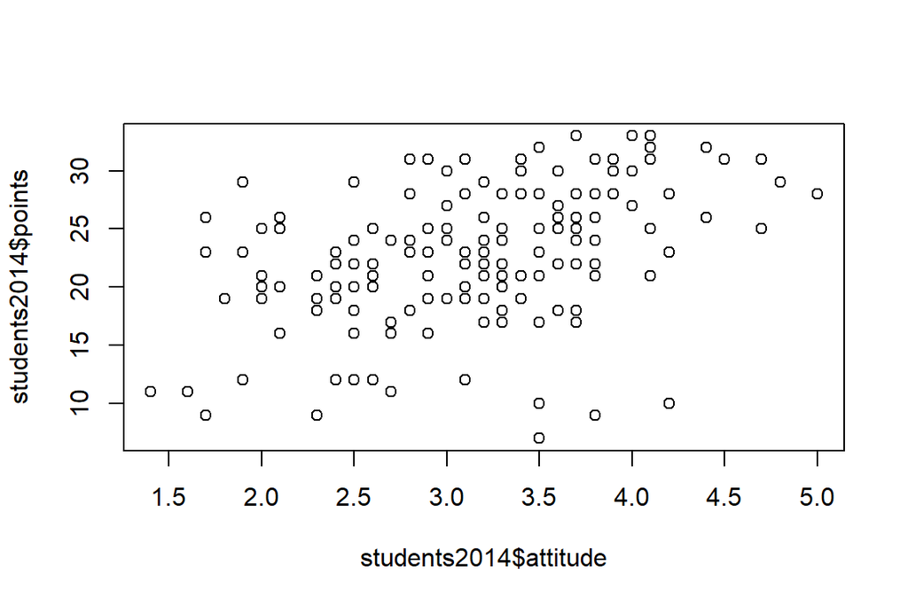

```r
plot(students2014$attitude, students2014$points)
```

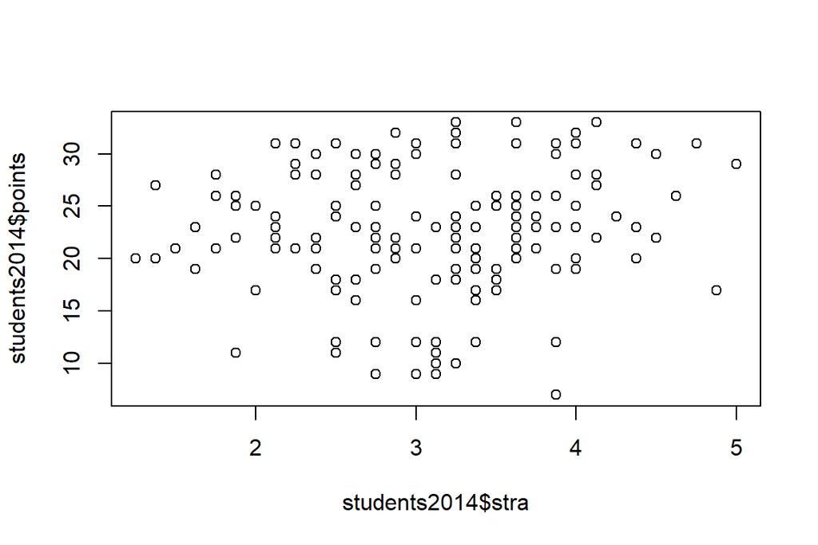

```r
plot(students2014$stra, students2014$points)
```

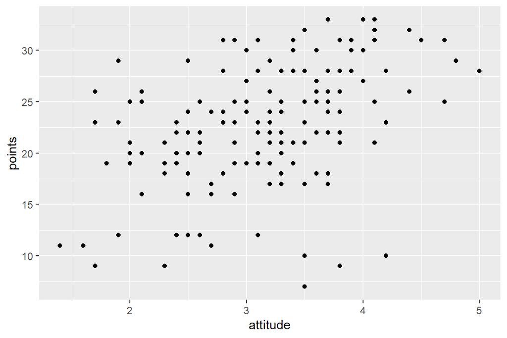

```r
p1 <- ggplot(students2014, aes(x = attitude, y = points))

p2 <- p1 + geom_point()

p2
```